# Different Models

## Background

I’ve created three different types of regression models with arbitrary parameters of my choosing which I used to generate data around each model. The goa is to create an estimate for each model parameter, and see how close the estimate gets to the ‘true’ model.

## Quadratic Model

$$Y_i = \beta_0 + \beta_1 X_i + \beta_2X_i^2 + \epsilon_i$$

The true regression model used to generate the data is

$E\{Y_i\} = -1000 + 70X_i - 1X_i^2$, represented by the solid blue line.

This was estimated to be

$\hat{Y_i} = -872.9173 + 60.467X_i - .843X_i^2$, shown using the dotted blue line.

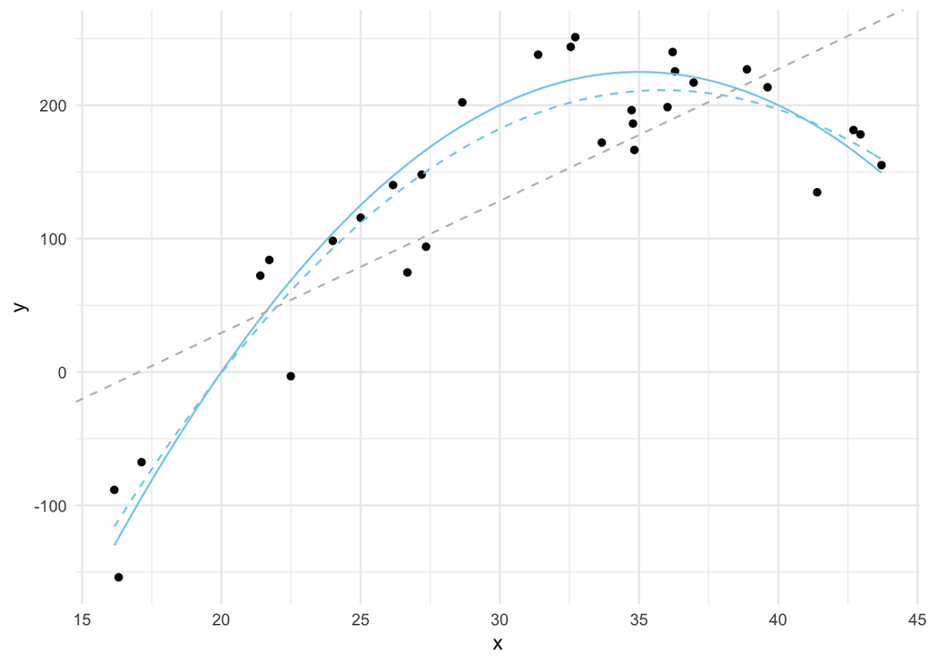

| Model | $R^2$ | Adjusted $R^2$ |
| --- | --- | --- |
| Simple | 0.6084701 | 0.5944869 |
| Quadratic | 0.8902181 | 0.8820861 |

```r
X_i <- runif(n, 15, 45)
#Gives n random values from a uniform distribution between 15 to 45.

beta0 <- -1000 #Our choice for the y-intercept.
beta1 <- 70 #Our choice for the slope.
beta2 <- -1
sigma <- 35 #Our choice for the std. deviation of the error terms.


epsilon_i <- rnorm(n, 0, sigma)
#Gives n random values from a normal distribution with mean = 0, st. dev. = sigma.

Y_i <- beta0 + beta1*X_i + beta2*X_i^2 + epsilon_i
#Create Y using the normal error regression model

fabData <- data.frame(y=Y_i, x=X_i)

#In the real world, we begin with data (like fabData) and try to recover the model that
# (we assume) was used to created it.

fab.lm <- lm(y ~ x + I(x^2), data=fabData) #Fit an estimated regression model to the fabData.
simple.lm <- lm(y ~ x, data=fabData)

b <- coef(fab.lm)

ggplot(fabData) +
  geom_point(aes(y = y, x = x)) +
  stat_function(fun = function(x) beta0 + beta1 * x + beta2 * x^2, color = "skyblue") +
  stat_function(fun = function(x) b[1] + b[2] * x + b[3] * x^2, linetype="dashed", color="skyblue") +
  geom_abline(intercept = simple.lm$coefficients[1], slope = simple.lm$coefficients[2], color="gray", linetype="dashed") +
  labs(main = "test") +
  theme_minimal()
```

## Two-lines Regression Model

$$Y_i = \beta_0 + \beta_1 X_1i + \beta_2X_2i + \beta_3 X_1i X_2i + \epsilon_i$$

```r
beta0 <- 5 #Our choice for the y-intercept.
beta1 <- 35 #Our choice for the slope.
sigma <- 250 #Our choice for the std. deviation of the error terms.

beta0_2 <- 10 #Our choice for the y-intercept.
beta1_2 <- 65 #Our choice for the slope.
sigma_2 <- 150 #Our choice for the std. deviation of the error terms.

X_i <- runif(n, 15, 45)
X_i2 <- runif(n, 15, 45)

epsilon_i <- rnorm(n, 0, sigma)
epsilon_i2 <- rnorm(n, 0, sigma_2)

Y_i <- beta0 + beta1*X_i + epsilon_i
Y_i2 <- beta0_2 + beta1_2*X_i2 + epsilon_i2

fabData <- data.frame(y=Y_i, x=X_i, type='one')
fabData <- rbind(fabData, data.frame(y=Y_i2, x=X_i2, type='two'))

# plot(y ~ x, data=fabData, col=c("skyblue", "orange")[as.factor(type)], pch=21, cex.main=1)

multi.lm <- lm(y ~ x + type + x:type, data=fabData)
simple.lm <- lm(y ~ x, data=fabData)

b <- coef(multi.lm)
```

The estimated models are

$\hat{Y_i} = -79.7621954 + 39.6825765X_i$ (dashed red line).

$\hat{Y_i} = (-79.7621954 + 86.9549609) + (39.6825765 + 24.1076097)X_i$ (dashed blue line)

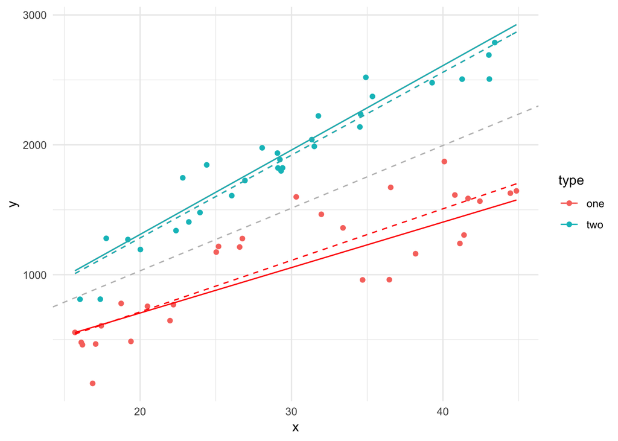

| Model | $R^2$ | Adjusted $R^2$ |
| --- | --- | --- |
| Simple | 0.4729611 | 0.4638743 |
| Two-lines | 0.9029342 | 0.8977343 |

```r
ggplot(fabData, aes(y = y, x = x, color=as.factor(type))) +
  geom_point() +
  labs(color="type") +
  stat_function(fun = function(x) beta0 + beta1*x, color="red") +
  stat_function(fun = function(x) b[1] + b[2]*x, linetype="dashed", color="red") +
  stat_function(fun = function(x) beta0_2 + beta1_2*x) +
  stat_function(fun = function(x) (b[1] + b[3]) + (b[2] + b[4])*x, linetype="dashed") +
  geom_abline(intercept = simple.lm$coefficients[1], slope = simple.lm$coefficients[2], color="gray", linetype="dashed") +
  theme_minimal()
```

## Cubic Model

$$Y_i = \beta_0 + \beta_1 X_i + \beta_2X_i^2 + \beta_3X_i^3 + \epsilon_i$$

```r
set.seed(101) #gives us the same randomness
n <- 20 #sample size
X <- runif(n, -1.5, 2)

beta0 <- 1
beta1 <- -.1
beta2 <- 2.5
beta3 <- .5

Y <- beta0 + beta1*X + beta2*X^2 + beta3*X^3 + rnorm(n, 0, 1)


fake.lm <- lm(Y ~ X + I(X^2) + I(X^3), data = data.frame(Y=Y, X=X))
simple.lm <- lm(Y ~ X, data = data.frame(Y=Y, X=X))

b <- coef(fake.lm)
```

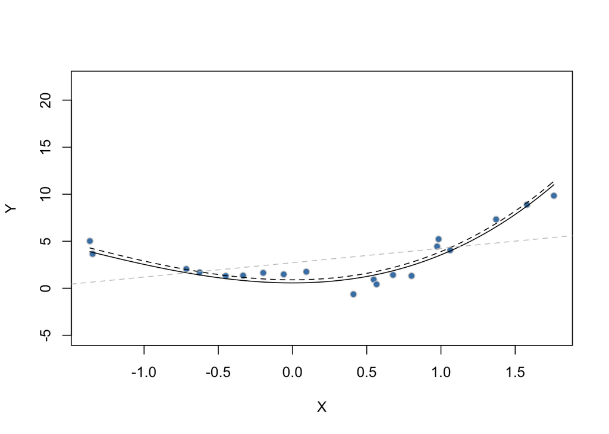

| Model | $R^2$ | Adjusted $R^2$ |
| --- | --- | --- |
| Simple | 0.235196 | 0.1927069 |
| Cubic | 0.9020112 | 0.8836384 |

```r
plot(Y ~ X, pch=21, col="lightgray", bg="steelblue", ylim=c(-5,22))

fabulousData <- data.frame(y = Y, x = X)

curve(b[1] + b[2] + b[3]*x^2 + b[4]*x^3, add = T)
curve(beta0 + beta1 + beta2*x^2 + beta3*x^3, add = T, lty = 2)
abline(simple.lm, lty=2, col="gray", lwd=.8)
```

## Example with real dataset

I used the mtcars dataset to explain miles per gallon using horsepower. I applied a simple, quadratic, and cubic model. Both the cubic and quadratic model seemed to fit the data similarly, and they did a decent job, at least better than the simple regression.

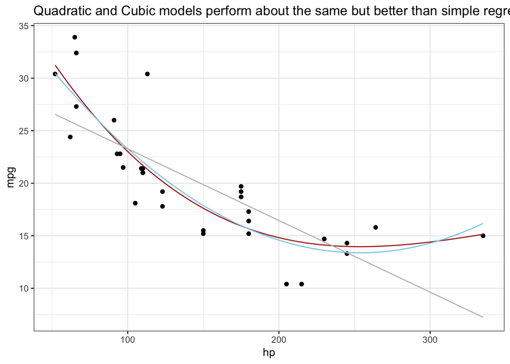

```r
wage.cube.lm <- lm(mpg ~ hp + I(hp^2) + I(hp^3), data = mtcars)
wage.quad.lm <- lm(mpg ~ hp + I(hp^2), data = mtcars)
wage.simple.lm <- lm(mpg ~ hp, data = mtcars)
b <- coef(wage.cube.lm)
b2 <- coef(wage.quad.lm)
b3 <- coef(wage.simple.lm)

# curve(b[1] + b[2] * x + b[3] * x^2 + b[4] * x^3, add = T)
# curve(b2[1] + b2[2] * x + b2[3] * x^2, add = T)
# abline(wage.simple.lm)

ggplot(mtcars, aes(y= mpg, x = hp)) +
  geom_point() +
  stat_function(fun = function(x) b[1] + b[2] * x + b[3] * x^2 + b[4] * x^3, color="firebrick") +
  stat_function(fun = function(x) b2[1] + b2[2] * x + b2[3] * x^2, color="skyblue") +
  stat_function(fun = function(x) b3[1] + b3[2] * x, color="gray") +
  labs(title = "Quadratic and Cubic models perform about the same but better than simple regression model") +
  theme_bw()
```

**Quadratic model:**

In the quadratic model the estimate of $\beta_0$, 40.4091172 is the y-intercept, the estimate for $\beta_1$, -0.2133083 will be used to determine where the vertex of the parabola is ($\frac{−\beta_1}{2\cdot\beta_2}$). The estimate for $\beta_2$, 0.0004208 determines which direction the parabola will face and how “steep” it is - larger values make for a steeper parabola.

**Cubic model:**

$\hat{Y_i} = 44.22 + -0.2945X_i + 0.0009115X_i^2 - 8.701086e-07X_i^3$

In this model, the 44.22 ($\beta_0$) estimate represents the Y-intercept as usual. -0.2945 ($\beta_1$) is not so easily interpreted but can be thought of as contributing to the location of the local minimum and maximum values. 0.0009115 ($\beta_2$) is similar to $\beta_1$. -8.701e-07 ($\beta_3$) determines whether the model is increasing or decreasing depending on it’s sign.

**Two-line model:**

I’ll use the same old dataset as everyone else for the two-line model, where an automatic transmission is represented as 0 so that it can cancel out part of the equation and a manual transmission is 1. The big twist is that I’m predicting qsec based on mpg.

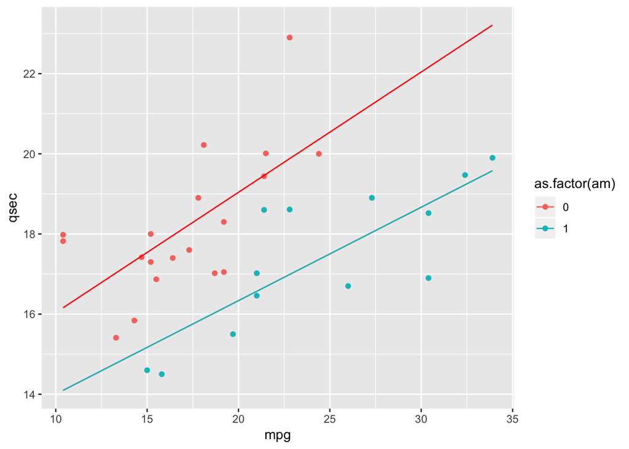

```r
m.lm <- lm(qsec ~ mpg + am + mpg:am, data = mtcars)

b <- coef(m.lm)

ggplot(mtcars, aes(x = mpg, y = qsec, colour=as.factor(am))) +
  geom_point() +
  stat_function(fun = function(x) b[1] + b[2]*x, color="red") +
  stat_function(fun = function(x) (b[1] + b[3]) + (b[2] + b[4])*x)
```

When the transmission is 0, it actas as the baseline using the following model:

$$\hat{Y}_i = \overbrace{13.04}^{\stackrel{\text{y-int}}{\text{baseline}}} + \overbrace{0.3}^{\stackrel{\text{slope}}{\text{baseline}}} X_{1i}$$

When transmission is 1, we add the difference in y-intercept and slope, which is what $\beta_2$ and $\beta_3$ estimate respectively ($\beta_3$ is known as the “interaction” term), to the baseline y-intercept and slope to get the equation for the second line:

$$\hat{Y}_i = \underbrace{(\overbrace{13.04}^{\stackrel{\text{y-int}}{\text{baseline}}} - \overbrace{1.36}^{\stackrel{\text{change in}}{\text{y-int}}})}_{\stackrel{\text{y-intercept}}{11.68}} + \underbrace{(\overbrace{.3}^{\stackrel{\text{slope}}{\text{baseline}}} - \overbrace{0.07}^{\stackrel{\text{change in}}{\text{slope}}})}_{\stackrel{\text{slope}}{.23}} X_{1i}$$